# [과제11] 모집단이 두 개인 경우 (독립표본, 대응표본) + 모집단이 세 개인 경우 (ANOVA, 적합도/독립성 검정)

# Paired sample T-test

### **문제 1.**

#### 새로운 당뇨병 치료제를 개발한 제약사에서는 치료에 지대한 영향을 주는 외부요인을 통제하기 위해 10명의 당뇨병 환자를 선별하여 1달 동안 ’위약(placebo)’을 투여한 기간의 혈당 수치(Xi)와 ’신약(new medicine)’을 투여한 1달 기간 동안의 혈당 수치(Yi)를 측정하여 짝을 이루어 혈당 차이를 유의수준 5%에서 비교하시오.

```
##
##  Shapiro-Wilk normality test
##
## data:  D
## W = 0.92988, p-value = 0.4467
```

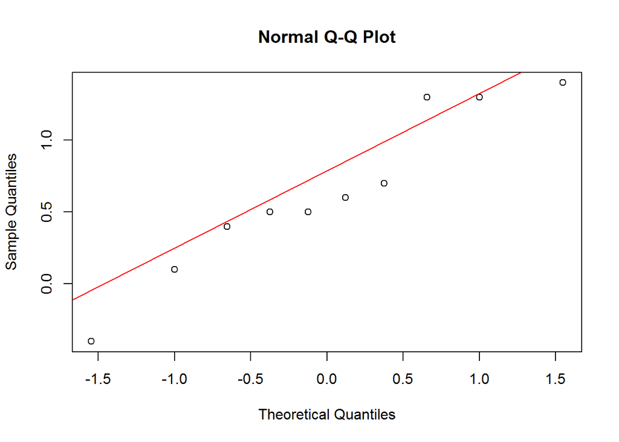

```r
# D = mu1 - mu2

# 0 정규성 검정
placebo <- c(51.4, 52, 45.5, 54.5, 52.3, 50.9, 52.7, 50.3, 53.8, 53.1)
new <- c(50.1, 51.5, 45.9, 53.1, 51.8, 50.3, 52, 49.9, 52.5, 53)
D <- placebo - new

shapiro.test(D); qqnorm(D); qqline(D, col="red")
```

```r
# 검정결과, p-value의 값이 0.4467로 유의수준 0.05보다 크다. 따라서 혈당 수치의 차이는 정규분포를 따른다고 결론내리고, 이에 따라 paired sample T-test를 실시한다.
```

```r
# 1. 가설설정

# H0 : 당뇨병 치료제는 효과가 없다 (mu1-mu2=0) == D = 0
# H1 : 당뇨병 치료제는 효과가 있다 (혈당수치가 낮아지는 게 효과가 있으므로 mu1-mu2>0, 우측검정) D > 0

# 2. 판정
t.test(placebo, new, alternative = "greater", paired = T, conf.level = 0.95)
```

```
##
##  Paired t-test
##
## data:  placebo and new
## t = 3.5507, df = 9, p-value = 0.003105
## alternative hypothesis: true difference in means is greater than 0
## 95 percent confidence interval:
##  0.3095874       Inf
## sample estimates:
## mean of the differences
##                    0.64
```

```r
mean(D); sd(D)
```

```
## [1] 0.64
```

```
## [1] 0.5699903
```

```r
# 3. 결론

# 새로운 당뇨병 치료제가 혈당수치를 낮추는지 알아보기 위해 10명의 표본을 추출하여 신약 투약 전과 후 혈당수치를 측정하여
# 혈당수치의 차이를 구한 결과 혈당수치가 평균 0.64 감소하였으며, 표준편차는 0.56으로 나타났다. 또한 유의수준 0.05에서
# 검정통계량과 유의확률은 3.5507(p = 0.0031)으로 나타나 "신약은 혈당수치를 낮추는데 효과가 있다"는 통계적으로 유의한 결론을 얻을 수 있다.
# 즉, 새로운 당뇨병 치료제는 혈당수치를 낮추는 효과가 있는 것으로 판단된다.
```

### **문제 2.**

#### 두 종류의 신발 밑창의 원재료가 닳는 정도가 차이가 있는지를 검정하기 위해서 10명의 소년에게 한쪽은 A라는 원재료로 만든 신발을 신기고, 다른 한쪽은 B라는 원재료로 만든 신발을 신긴 후에, 일정 기간이 지난후에 신발을 수거하여 10명의 각 소년의 왼쪽 신발 밑창의 닳은 정도와 오른쪽 신발 밑창의 닳은 정도의 차이를 비교하여 두 종류 원재료의 재질이 다른지를 검정하시오. (유의수준 0.05)

```r
# 0. 정규성 검정
A <- c(13.2, 8.2, 10.9, 14.3, 10.7, 6.6, 9.5, 10.8, 8.8, 13.3)
B <- c(14, 8.8, 11.2, 14.2, 11.8, 6.4, 9.8, 11.3, 9.3, 13.6)
D <- A-B

shapiro.test(D)
```

```
##
##  Shapiro-Wilk normality test
##
## data:  D
## W = 0.96132, p-value = 0.8009
```

```r
# 검정결과, p-value의 값이 0.8009로 유의수준 0.05보다 크다. 따라서 신발 밑창의 닳은 정도의 차이는 정규분포를 따른다고 결론내리고, 이에 따라 paired sample T-test를 실시한다.



# 1. 가설설정

# H0 : 두 종류의 신발 밑창 원재료는 닳는 정도가 같다 (D=0)
# H1 : 두 종류의 신발 밑창 원재료는 닳는 정도가 다르다 (D!=0)



# 2. 판정

t.test(A, B, paired = T, alternative = "two.sided", conf.level = 0.95)
```

```
##
##  Paired t-test
##
## data:  A and B
## t = -3.3489, df = 9, p-value = 0.008539
## alternative hypothesis: true difference in means is not equal to 0
## 95 percent confidence interval:
##  -0.6869539 -0.1330461
## sample estimates:
## mean of the differences
##                   -0.41
```

```r
mean(D); sd(D) # D의 평균과 표준편차
```

```
## [1] -0.41
```

```
## [1] 0.3871549
```

```r
# 3. 결론

# 두 종류의 신발 밑창의 원재료가 닳는 정도가 차이가 있는지 알아보기 위해 10명의 표본에게 한 쪽은 A원재료로, 다른 한 쪽은 B원재료로 만든
# 신긴 후 닳는 정도의 차이가 있는지 파악한 결과 두 재료의 차이가 평균 -0.41이었으며, 표준편차가 0.3871로 나타났다.
# 또한 유의수준 5%에서 검정통계량과 유의확률은 -3.3489( p = 0.0085)로 나타나 "두 원재료로 만든 신발의 밑창이 닳는 정도가 다르다"는
# 통계적으로 유의한 결과를 낼 수 있다. 즉, 두 재료로 만든 신발의 닳는 정도는 차이가 있다고 판단된다.
```

# 일원배치분산분석(ANOVA)

### **문제 1.**

#### 다음은 3개 호수의 산소량의 차이가 있는지 없는지 알아보기 위하여 각 호수에서 10곳을 선택하여 수심 1m의 물로부터 산소량(ppm)을 측정한 자료이다. 3개 호수의 산소량이 같다고 할 수 있는가?

```r
# 정규성 검정
library(reshape)
```

```
##
##  Shapiro-Wilk normality test
##
## data:  ppm$l1
## W = 0.93369, p-value = 0.4851
```

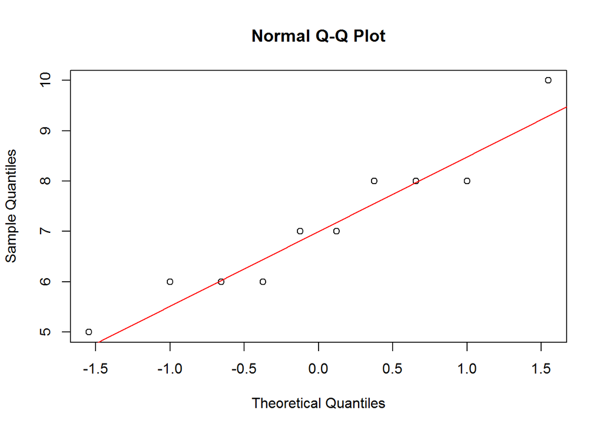

```r
library(dplyr)
ppm <- data.frame(l1 = c(5,7,6,8,6,7,8,8,6,10),
                l2 = c(6,8,9,11,13,12,10,8,9,10),
                l3 = c(14,25,26,18,19,22,21,16,20,30))

shapiro.test(ppm$l1); qqnorm(ppm$l1); qqline(ppm$l1, col="red")
```

```
##
##  Shapiro-Wilk normality test
##
## data:  ppm$l2
## W = 0.98106, p-value = 0.9706
```

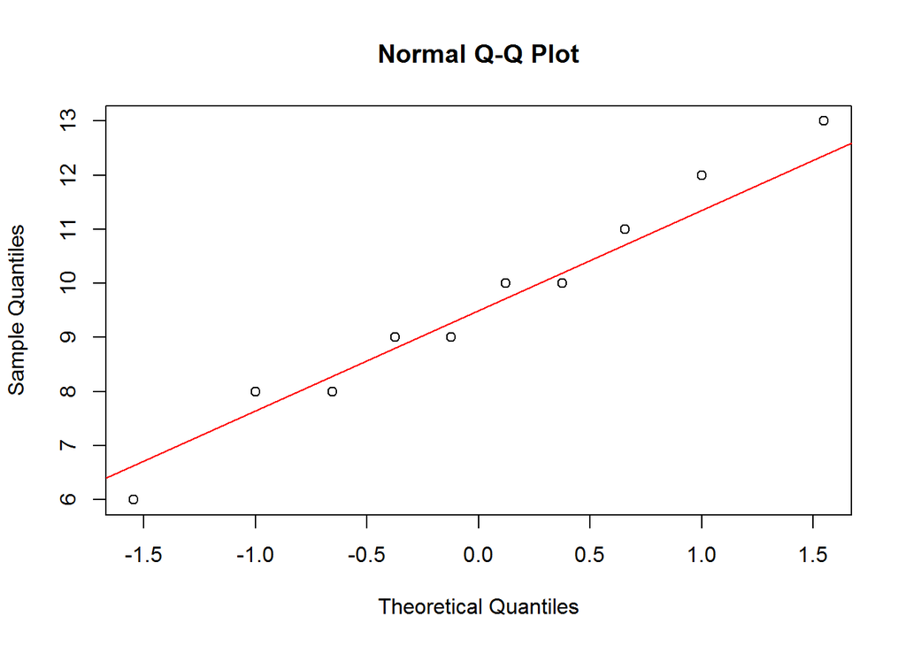

```r
shapiro.test(ppm$l2); qqnorm(ppm$l2); qqline(ppm$l2, col="red")
```

```
##
##  Shapiro-Wilk normality test
##
## data:  ppm$l3
## W = 0.98022, p-value = 0.9663
```

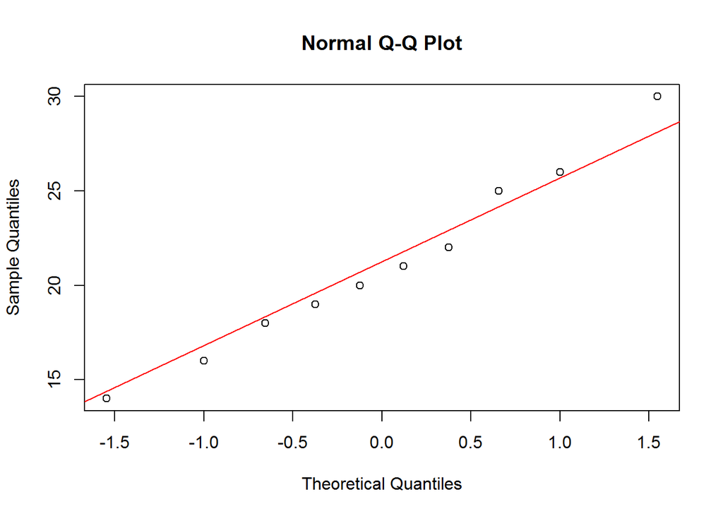

```r
shapiro.test(ppm$l3); qqnorm(ppm$l3); qqline(ppm$l3, col="red")
```

```r
# 검정결과, 모든 호수에 대한 p-value가 유의수준 0.05보다 크게 나왔다. 따라서 각 호수에 대한 산소량은 모두 정규분포를 따른다고 결론내린다.


# 등분산성 검정

# 이제 각 호수 별 산소량에 대한 분산이 모두 동일한 지 검정한다. 이에 대해서는 Levene의 검정과 Bartlett의 검정이 있다. 모두 세집단 이상의 경우에 대해 등분산성을 검정 시 사용하는 검정법이고 해당 통계량이 특정한 분포에 근사한다는 성질을 이용한다

ppm2 <- ppm %>% melt()
```

```
## Using  as id variables
```

```r
# levene.test
library(lawstat) # ANOVA 분석에서 등분산성 검정
levene.test(ppm2$value, ppm2$variable)
```

```
##
##  Modified robust Brown-Forsythe Levene-type test based on the
##  absolute deviations from the median
##
## data:  ppm2$value
## Test Statistic = 5.2762, p-value = 0.01164
```

```r
# bartlett.test
bartlett.test(value ~ variable, ppm2)
```

```
##
##  Bartlett test of homogeneity of variances
##
## data:  value by variable
## Bartlett's K-squared = 13.214, df = 2, p-value = 0.001351
```

```r
# 검정결과, 두가지 검정 모두 p-value의 값이 유의수준 0.05보다 작게 나왔다. 따라서 귀무가설을 기각하게 되고, 호수 별 산소량에 대한 분산은 차이가 있다고 결론내린다. 하지만, 각각 호수 별 10개씩 동일한 개수의 표본을 추출하였으므로 이 경우에는 분산분석을 적용하는 데 문제가 없다.


# 1. 가설설정
# H0 : 각 호수의 산소량이 같다.
# H1 : 적어도 하나의 호수의 산소량이 다르다

# 2. 판정
anova(lm(value ~ variable, data=ppm2))
```

```
## Analysis of Variance Table
##
## Response: value
##           Df Sum Sq Mean Sq F value    Pr(>F)
## variable   2 1115.0  557.50  56.124 2.411e-10 ***
## Residuals 27  268.2    9.93
## ---
## Signif. codes:  0 '***' 0.001 '**' 0.01 '*' 0.05 '.' 0.1 ' ' 1
```

```r
ppm2 %>%
  group_by(variable) %>%
  summarise(mean = mean(value),
            sd = sd(value))
```

```
## # A tibble: 3 x 3
##   variable  mean    sd
##   <fct>    <dbl> <dbl>
## 1 l1         7.1  1.45
## 2 l2         9.6  2.07
## 3 l3        21.1  4.84
```

```r
# 3. 결론

# 3군데 호수의 산소량이 차이가 있는지 없는지 알아보기 위해 각 호수에 10곳을 선택하여 수심 1m의 물로부터 산소량을 측정한 결과
# 호수 1의 산소량의 평균과 표준편차는 7.1 ± 1.45(ppm)
# 호수 2의 산소량의 평균과 표준편차는 9.6 ± 2.07(ppm)
# 호수 3의 산소량의 평균과 표준편차는 21.1 ± 4.84(ppm)로 나타났다.
# 또한 일원분산분석을 통해 각 호수의 산소량(ppm)을 검정한 결과, 검정통계량과 유의확률은 56.124(p=2.411e-10)로 유의수준 5% 에서
# 통계적으로 아주 유의한 차이를 보였습니다. 즉, 호수에 따른 산소량의 평균은 차이가 나는 것으로 나타났다.
# 다만, 어느 집단과의 차이가 통계적으로 유의한지 사후검정이 필요하다.



# 4. 사후검정
# 그렇다면, 과연 어느 집단에서 차이가 발생하는 지 다중비교를 통해서 확인해보자. 이에 해당하는 방법에는 Tukey의 HSD, Duncan, Scheffe 등 다양한 방법이 존재하고, 모두 특정한 통계량을 계산하여 그 통계량과 각 집단에 대한 표본평균 값의 차이를 비교하여 그룹을 나누게 된다. 다만, Tukey의 HSD 방법이 가장 유연하고, Scheffe의 방법이 가장 엄격하다고 알려져 있다.
```

#### **Tukey HSD**

```r
out <- aov(lm(value ~ variable, data=ppm2)) # anova 모형
(ph <- TukeyHSD(out))
```

```
##   Tukey multiple comparisons of means
##     95% family-wise confidence level
##
## Fit: aov(formula = lm(value ~ variable, data = ppm2))
##
## $variable
##       diff        lwr       upr     p adj
## l2-l1  2.5 -0.9947185  5.994718 0.1974223
## l3-l1 14.0 10.5052815 17.494718 0.0000000
## l3-l2 11.5  8.0052815 14.994718 0.0000000
```

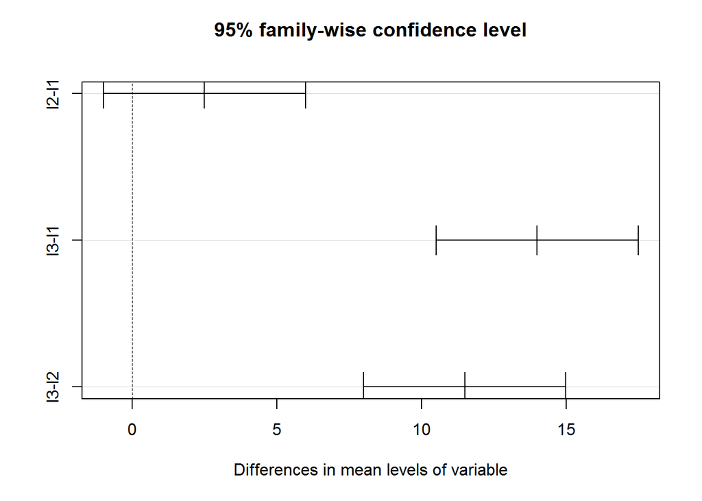

```r
plot(ph)
```

```r
# 위의 결과에서 맨 오른쪽의 p-value 값을 확인해보면 ‘호수2-호수1’ 을 제외하고는 모두 유의수준 0.05보다 굉장히 작은 값이다. 그러므로 호수3의 산소량이 호수1과 호수2와 비교했을 때 현저히 차이가 난다고 볼 수 있고, 호수1과 호수2의 경우는 차이가 그리 유의하지 않다고 말할 수 있다.
```

#### **Duncan**

```r
library(agricolae)  # Duncan, Scheffe test
(res1 <- duncan.test(out, "variable", alpha=0.05, group = T, console = T))
```

```
##
## Study: out ~ "variable"
##
## Duncan's new multiple range test
## for value
##
## Mean Square Error:  9.933333
##
## variable,  means
##
##    value      std  r Min Max
## l1   7.1 1.449138 10   5  10
## l2   9.6 2.065591 10   6  13
## l3  21.1 4.840799 10  14  30
##
## Alpha: 0.05 ; DF Error: 27
##
## Critical Range
##        2        3
## 2.892038 3.038482
##
## Means with the same letter are not significantly different.
##
##    value groups
## l3  21.1      a
## l2   9.6      b
## l1   7.1      b
```

[output not shown]

```r
(res2 <- scheffe.test(out,"variable", alpha=0.05, group = T, console = T))
```

```
##
## Study: out ~ "variable"
##
## Scheffe Test for value
##
## Mean Square Error  : 9.933333
##
## variable,  means
##
##    value      std  r Min Max
## l1   7.1 1.449138 10   5  10
## l2   9.6 2.065591 10   6  13
## l3  21.1 4.840799 10  14  30
##
## Alpha: 0.05 ; DF Error: 27
## Critical Value of F: 3.354131
##
## Minimum Significant Difference: 3.650627
##
## Means with the same letter are not significantly different.
##
##    value groups
## l3  21.1      a
## l2   9.6      b
## l1   7.1      b
```

[output not shown]

```r
# 분석결과, Duncan, Schaffe 모두 호수1과 호수2의 산소량은 차이가 미비하고, 나머지 호수3의 산소량이 나머지 두 집단과 차이가 있다는 결론을 주고 있다. 결과적으로 3가지 다중비교 방법 모두 같은 결론을 제시하고 있다.
```